# Video Game Genre Classification

Jerry Parng

The goal of this project is to classify video game genres using attributes such as publisher, sales, and platform. The dataset is from Kaggle.com by user Ulrik Thyge Pedersen.

Kaggle Link: https://www.kaggle.com/datasets/ulrikthygepedersen/video-games-sales?resource=download

```r
video_game <- read.csv("video_games_sales.csv", stringsAsFactors = TRUE)
unique(video_game$genre)
```

```
 [1] Sports       Platform     Racing       Role-Playing Puzzle       Misc         Shooter      Simulation   Action       Fighting     Adventure    Strategy
Levels: Action Adventure Fighting Misc Platform Puzzle Racing Role-Playing Shooter Simulation Sports Strategy
```

## 1. Data Exploration

```r
str(video_game)
```

```
'data.frame':   16598 obs. of  11 variables:
 $ rank        : int  1 2 3 4 5 6 7 8 9 10 ...
 $ name        : Factor w/ 11493 levels "'98 Koshien",..: 10991 9343 5532 10993 7364 9707 6648 10989 6651 2594 ...
 $ platform    : Factor w/ 31 levels "2600","3DO","3DS",..: 26 12 26 26 6 6 5 26 26 12 ...
 $ year        : num  2006 1985 2008 2009 1996 ...
 $ genre       : Factor w/ 12 levels "Action","Adventure",..: 11 5 7 11 8 6 5 4 5 9 ...
 $ publisher   : Factor w/ 579 levels "","10TACLE Studios",..: 369 369 369 369 369 369 369 369 369 369 ...
 $ na_sales    : num  41.5 29.1 15.8 15.8 11.3 ...
 $ eu_sales    : num  29.02 3.58 12.88 11.01 8.89 ...
 $ jp_sales    : num  3.77 6.81 3.79 3.28 10.22 ...
 $ other_sales : num  8.46 0.77 3.31 2.96 1 0.58 2.9 2.85 2.26 0.47 ...
 $ global_sales: num  82.7 40.2 35.8 33 31.4 ...
```

```r
summary(video_game)
```

```
      rank                                name          platform         year               genre                             publisher        na_sales          eu_sales
 Min.   :    1   Need for Speed: Most Wanted:   12   DS     :2163   Min.   :1980   Action      :3316   Electronic Arts             : 1351   Min.   : 0.0000   Min.   : 0.0000
 1st Qu.: 4151   FIFA 14                    :    9   PS2    :2161   1st Qu.:2003   Sports      :2346   Activision                  :  975   1st Qu.: 0.0000   1st Qu.: 0.0000
 Median : 8300   LEGO Marvel Super Heroes   :    9   PS3    :1329   Median :2007   Misc        :1739   Namco Bandai Games          :  932   Median : 0.0800   Median : 0.0200
 Mean   : 8301   Madden NFL 07              :    9   Wii    :1325   Mean   :2006   Role-Playing:1488   Ubisoft                     :  921   Mean   : 0.2647   Mean   : 0.1467
 3rd Qu.:12450   Ratatouille                :    9   X360   :1265   3rd Qu.:2010   Shooter     :1310   Konami Digital Entertainment:  832   3rd Qu.: 0.2400   3rd Qu.: 0.1100
 Max.   :16600   Angry Birds Star Wars      :    8   PSP    :1213   Max.   :2020   Adventure   :1286   THQ                         :  715   Max.   :41.4900   Max.   :29.0200
                 (Other)                    :16542   (Other):7142   NA's   :271    (Other)     :5113   (Other)                     :10872
    jp_sales         other_sales        global_sales
 Min.   : 0.00000   Min.   : 0.00000   Min.   : 0.0100
 1st Qu.: 0.00000   1st Qu.: 0.00000   1st Qu.: 0.0600
 Median : 0.00000   Median : 0.01000   Median : 0.1700
 Mean   : 0.07778   Mean   : 0.04806   Mean   : 0.5374
 3rd Qu.: 0.04000   3rd Qu.: 0.04000   3rd Qu.: 0.4700
 Max.   :10.22000   Max.   :10.57000   Max.   :82.7400
```

```r
colSums(is.na(video_game))
```

```
        rank         name     platform         year        genre    publisher     na_sales     eu_sales     jp_sales  other_sales global_sales
           0            0            0          271            0            0            0            0            0            0            0
```

```r
video_game <- na.omit(video_game)

colSums(is.na(video_game))
```

```
        rank         name     platform         year        genre    publisher     na_sales     eu_sales     jp_sales  other_sales global_sales
           0            0            0            0            0            0            0            0            0            0            0
```

```r
str(video_game)
```

```
'data.frame':   16327 obs. of  11 variables:
 $ rank        : int  1 2 3 4 5 6 7 8 9 10 ...
 $ name        : Factor w/ 11493 levels "'98 Koshien",..: 10991 9343 5532 10993 7364 9707 6648 10989 6651 2594 ...
 $ platform    : Factor w/ 31 levels "2600","3DO","3DS",..: 26 12 26 26 6 6 5 26 26 12 ...
 $ year        : num  2006 1985 2008 2009 1996 ...
 $ genre       : Factor w/ 12 levels "Action","Adventure",..: 11 5 7 11 8 6 5 4 5 9 ...
 $ publisher   : Factor w/ 579 levels "","10TACLE Studios",..: 369 369 369 369 369 369 369 369 369 369 ...
 $ na_sales    : num  41.5 29.1 15.8 15.8 11.3 ...
 $ eu_sales    : num  29.02 3.58 12.88 11.01 8.89 ...
 $ jp_sales    : num  3.77 6.81 3.79 3.28 10.22 ...
 $ other_sales : num  8.46 0.77 3.31 2.96 1 0.58 2.9 2.85 2.26 0.47 ...
 $ global_sales: num  82.7 40.2 35.8 33 31.4 ...
 - attr(*, "na.action")= 'omit' Named int [1:271] 180 378 432 471 608 625 650 653 712 783 ...
  ..- attr(*, "names")= chr [1:271] "180" "378" "432" "471" ...
```

Since this project is looking at genre, the name variable is redundant as the rank variable would provide the same identification, thus the name variable will be removed.

```r
video_game <- subset(video_game, select =-(name))
```

```r
str(video_game)
```

```
'data.frame':   16327 obs. of  10 variables:
 $ rank        : int  1 2 3 4 5 6 7 8 9 10 ...
 $ platform    : Factor w/ 31 levels "2600","3DO","3DS",..: 26 12 26 26 6 6 5 26 26 12 ...
 $ year        : num  2006 1985 2008 2009 1996 ...
 $ genre       : Factor w/ 12 levels "Action","Adventure",..: 11 5 7 11 8 6 5 4 5 9 ...
 $ publisher   : Factor w/ 579 levels "","10TACLE Studios",..: 369 369 369 369 369 369 369 369 369 369 ...
 $ na_sales    : num  41.5 29.1 15.8 15.8 11.3 ...
 $ eu_sales    : num  29.02 3.58 12.88 11.01 8.89 ...
 $ jp_sales    : num  3.77 6.81 3.79 3.28 10.22 ...
 $ other_sales : num  8.46 0.77 3.31 2.96 1 0.58 2.9 2.85 2.26 0.47 ...
 $ global_sales: num  82.7 40.2 35.8 33 31.4 ...
```

```r
attach(video_game)
```

Based on the side-by-side boxplots and ANOVA tests, the genre is associated with rank, year, and sales from NA,EU,JP, other, and global sales. Due to how many outliers there are for the sales attributes, 2 sets of boxplots are made where one has the outliers and the other has the outliers omitted for better visualization.

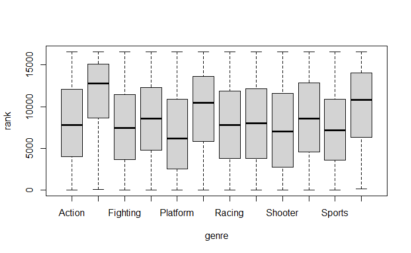

```r
library(ggplot2)
plot(rank~genre)
```

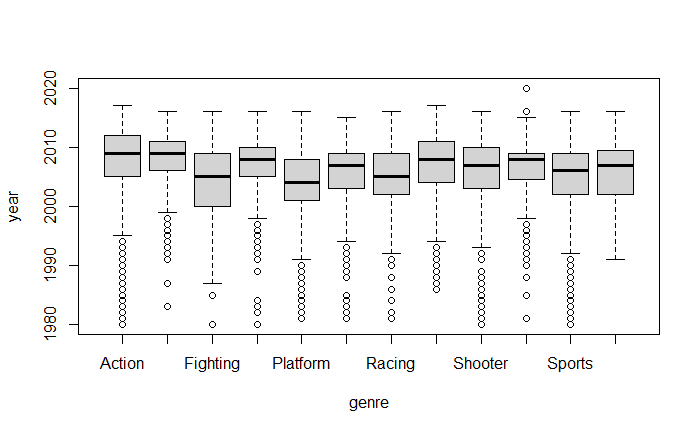

```r
plot(year~genre)
```

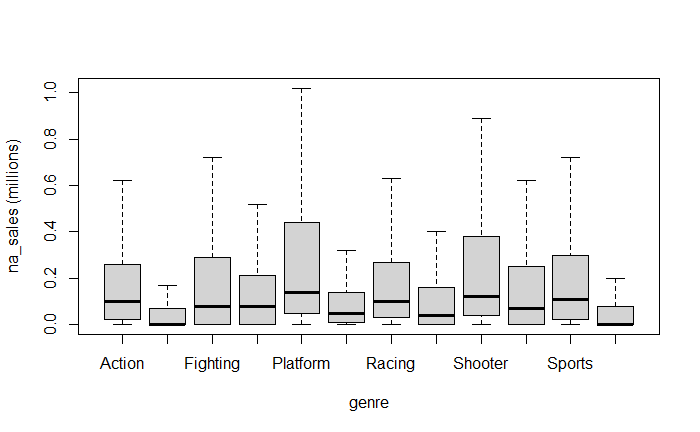

```r
plot(na_sales~genre, ylab = "na_sales (millions)", outline = FALSE)
```

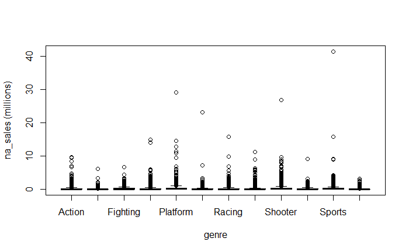

```r
plot(na_sales~genre, ylab = "na_sales (millions)")
```

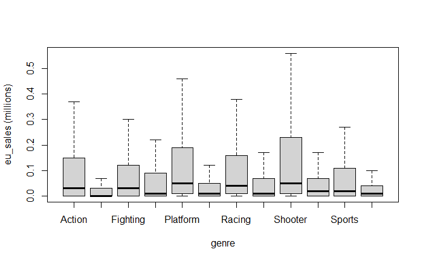

```r
plot(eu_sales~genre, ylab = "eu_sales (millions)", outline = FALSE)
```

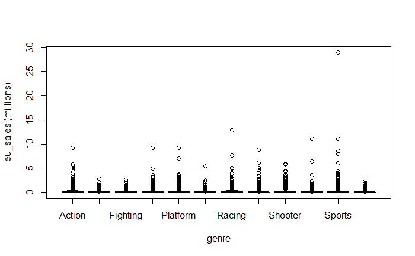

```r
plot(eu_sales~genre, ylab = "eu_sales (millions)")
```

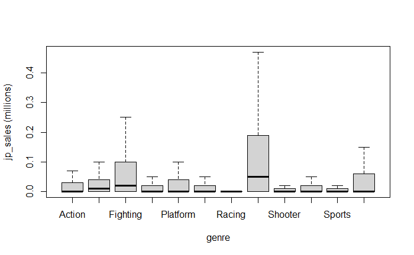

```r
plot(jp_sales~genre, ylab = "jp_sales (millions)", outline = FALSE)
```

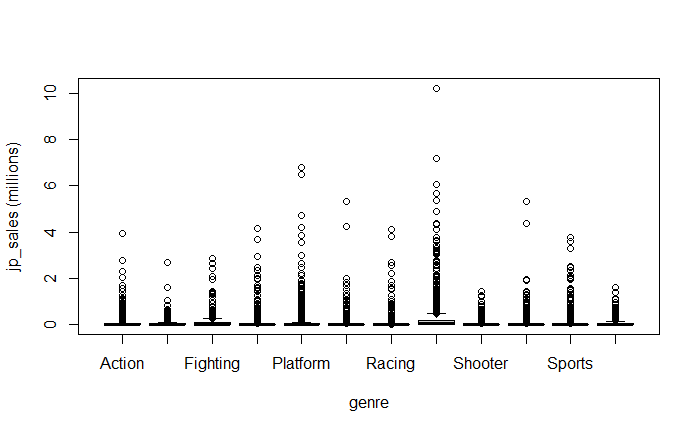

```r
plot(jp_sales~genre, ylab = "jp_sales (millions)")
```

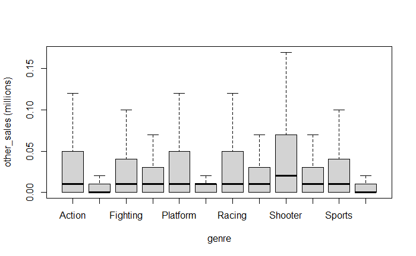

```r
plot(other_sales~genre, ylab = "other_sales (millions)", outline = FALSE)
```

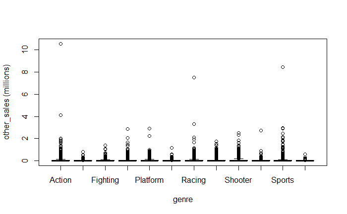

```r
plot(other_sales~genre, ylab = "other_sales (millions)")
```